# Metabolomics integration demonstration for MANA 2023

Sara Gosline (sara.gosline@pnnl.gov)

The goal of this document is to walk people through an end-to-end scenario using metabolomics to integrate with other omics data types. For the purposes of this work we are using metabolomics and proteomics data from the [CPTAC3 study on glioblastoma multiforme](https://www.sciencedirect.com/science/article/pii/S1535610821000507).

## Get RStudio

The first thin you’ll need to do is get RStudio. There are two ways to do this:

1. Download [R Studio Desktop](https://posit.co/download/rstudio-desktop/), which allows you to run everything on your local machine.
2. Register for a [free account](https://login.posit.cloud/register) so you can get access. Then create a ‘New Workspace’ and within that start a ‘New Project’. From here you will get a terminal that will look identical to an RStudio window on your local machine.

## Install packages, load data

Once you have a working R installation, we need to first install the required packages. This will require running the following `install.packages` commands by copying and pasting the text below. Some packages need to be installed from elsewhere such as [Bioconductor](http://bioconductor.org) or [GitHub](http://github.com). These are other repositories where packages are kept.

This requires pasting the commands below under the `if(FALSE)` clause

Lastly we read in a final set of commands that we have written ahead of this workshop using the `source` command. This will read in commands from a remote document indicated by the URL. You can take a peak at the script [here](https://github.com/sgosline/metabolomics-integration/blob/main/mixOmics/metabUtils.R), which contains some functions we created to help with the integration tasks below.

```r
if(FALSE){ ##copy and paste below
  install.packages('readr')
  install.packages('readxl')
  install.packages('tidyr')
  install.packages("dplyr")

  ##bioconductor has a lot of biology related packages
  install.packages("BiocManager")
  BiocManager::install('mixOmics')
#  BiocManager::install("limma")
  BiocManager::install('org.Hs.eg.db')
  BiocManager::install('topGO')
  BiocManagxer::install("KEGGgraph")

  ##remotes helps you install from github
  install.packages('remotes')
  remotes::install_github('sgosline/PCSF')
}

###now we load the libraries
library(readr)
library(readxl)
library(tidyr)
#library(limma)
library(dplyr)
library(mixOmics)
library(PCSF)

source("https://raw.githubusercontent.com/sgosline/metabolomics-integration/main/mixOmics/metabUtils.R")
```

Once all the installations are complete we can now move to processing the data.

## Load and summarize data

First we have to load the data. We store the metabolomics and proteomics data in files that are easily machine readable and can be read in through the `readr` library as shown below. These types of data are often stored in ‘wide’ form, where each row represents a protein or metabolite and each column represents a sample. I generally move these to ‘long’ form as it makes it easier to analyze, plot, and summarize.

```r
##metabolomics
##this reads in the glioblastoma metabolites
met <- readr::read_tsv("https://raw.githubusercontent.com/sgosline/metabolomics-integration/main/mixOmics/metabolome_pnnl.v4.0.20200430.tsv")


###here we read in metabolomic data, that also has the KEGG id included
kegg_met<-met|>
  dplyr::select(KEGG,Metabolite)|>
  distinct()|>
  tidyr::separate(KEGG,into=c('K1','K2','K3'),sep=',')|>
  tidyr::pivot_longer(cols=starts_with("K"),names_to='id',values_to='KEGG')|>
  subset(!is.na(KEGG))|>
  dplyr::select(-id)|>
  rowwise()|>
  mutate(compoundId=paste('cpd',KEGG,sep=':'))

cols<-union(grep("C3",colnames(met)),grep('PT',colnames(met)))

#now we move to long format
met<- met|>
  tidyr::pivot_longer(cols=cols,names_to='CPTAC Participant ID',values_to='intensity')|>
  dplyr::select(-KEGG)

##here is what long format looks like
print(head(met))
```

```
## # A tibble: 6 × 3
##   Metabolite            `CPTAC Participant ID` intensity
##   <chr>                 <chr>                      <dbl>
## 1 2-hydroxybutyric acid C3L-00365                   21.4
## 2 2-hydroxybutyric acid C3L-00674                   21.5
## 3 2-hydroxybutyric acid C3L-00677                   23.1
## 4 2-hydroxybutyric acid C3L-01043                   21.6
## 5 2-hydroxybutyric acid C3L-01045                   20.8
## 6 2-hydroxybutyric acid C3L-01048                   21.3
```

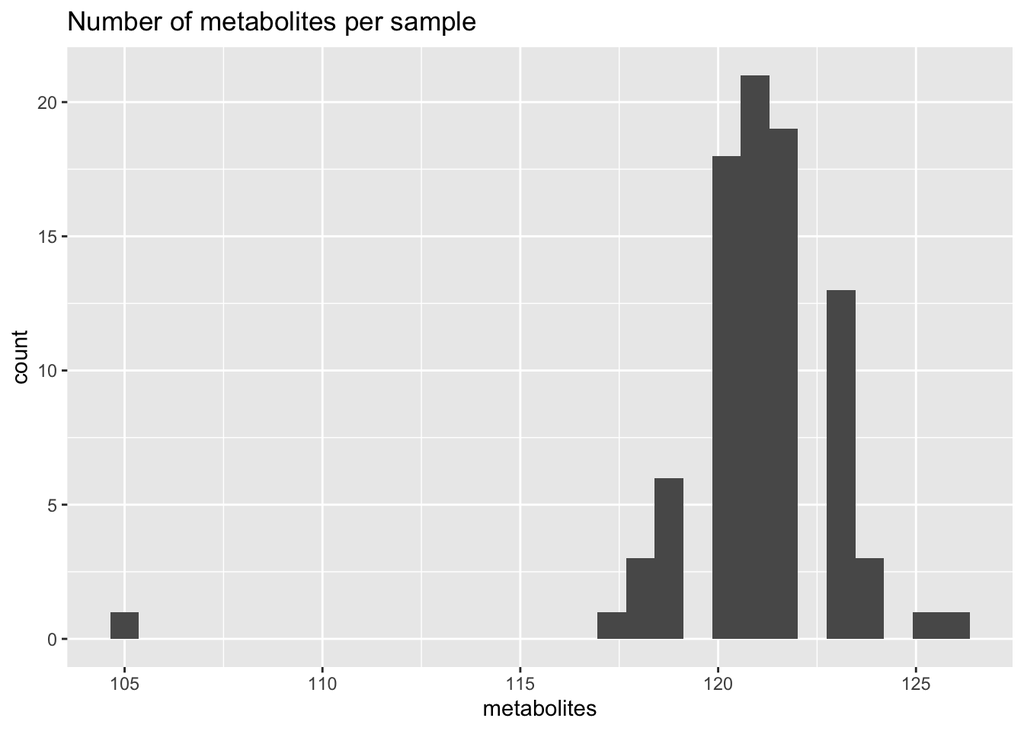

```r
#we can use R to do some summary statistics
mcounts<-met|>
    subset(!is.na(intensity))|>
    group_by(`CPTAC Participant ID`)|>
    summarize(metabolites=n_distinct(Metabolite))

##and plot a summary
mcounts|>
  ggplot(aes(x=metabolites))+geom_histogram()+ggtitle('Number of metabolites per sample')
```

Next we can read in the sample information to get relevant metadata about the samples and separate out the tumor vs. normal samples in our visualizations shown above. This again is a good sanity check on our data.

```r
##need this to map the samples
samps<-readr::read_tsv("https://raw.githubusercontent.com/sgosline/metabolomics-integration/main/mixOmics/sample_info.v4.0.20200430.tsv.gz")
protmapping <- readr::read_csv("https://raw.githubusercontent.com/sgosline/metabolomics-integration/main/mixOmics/GBM_TMT_plexes.csv")
print(head(protmapping))
```

```
## # A tibble: 6 × 8
##   `TMT plex` `TMT Channel` Alise `CPTAC Participant ID` `Parent Sample ID(s)`
##        <dbl> <chr>         <chr> <chr>                  <chr>
## 1          1 126           B1S1  ref                    <NA>
## 2          1 127N          B1S1  PT-Y8DK                GTEX-Y8DK-0011-R10A-SM-…
## 3          1 127C          B1S1  C3N-03183              C3N-03183-02, C3N-03183…
## 4          1 128N          B1S1  C3N-01505              C3N-01505-01
## 5          1 128C          B1S1  C3N-03188              C3N-03188-02
## 6          1 129N          B1S1  C3L-02984              C3L-02984-01,C3L-02984-…
## # ℹ 3 more variables: `Aliquot ID` <chr>, Type <chr>, Note <chr>
```

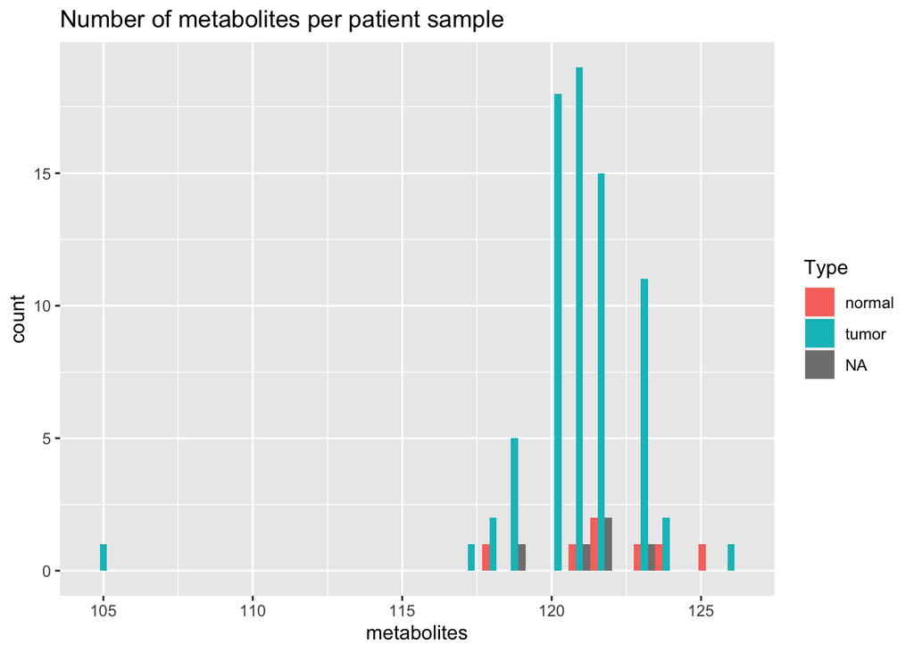

```r
mcounts|>left_join(protmapping)|>
  ggplot(aes(x=metabolites,fill=Type))+geom_histogram(position='dodge')+ggtitle("Number of metabolites per patient sample")
```

Now we can read in the proteomics data and join it with the sample information to recreate the plot for proteins.

```r
##now the proteomics
prot<-readr::read_tsv('https://raw.githubusercontent.com/sgosline/metabolomics-integration/main/mixOmics/GBM_PanCan_Proteome_UMich_UniProt_Sinai_observed_0205.tsv')|>
  tidyr::pivot_longer(cols=starts_with('CPT'),names_to='Aliquot ID',values_to='intensity')|>
  left_join(protmapping)|>
  dplyr::select(ApprovedGeneSymbol,intensity,`CPTAC Participant ID`,Type)|>
  distinct()

print(head(prot))
```

```
## # A tibble: 6 × 4
##   ApprovedGeneSymbol intensity `CPTAC Participant ID` Type
##   <chr>                  <dbl> <chr>                  <chr>
## 1 A1BG                    27.2 PT-Y8DK                normal
## 2 A1BG                    27.8 C3N-03183              tumor
## 3 A1BG                    28.0 C3N-01505              tumor
## 4 A1BG                    27.6 C3N-03188              tumor
## 5 A1BG                    27.0 C3L-02984              tumor
## 6 A1BG                    27.7 C3L-02542              tumor
```

```r
#we can use R to do some summary statistics
pcounts<-prot|>
    subset(!is.na(intensity))|>
    group_by(`CPTAC Participant ID`,Type)|>
    summarize(proteins=n_distinct(ApprovedGeneSymbol))

pcounts
```

| CPTAC Participant ID | Type | proteins |
| --- | --- | --- |
| C3L-00104 | tumor | 10703 |
| C3L-00365 | tumor | 11205 |
| C3L-00674 | tumor | 11360 |
| C3L-00677 | tumor | 11165 |
| C3L-01040 | tumor | 10700 |
| C3L-01043 | tumor | 11369 |
| C3L-01045 | tumor | 11166 |
| C3L-01046 | tumor | 11164 |
| C3L-01048 | tumor | 11259 |
| C3L-01049 | tumor | 11072 |

[output cut: 100 more lines]

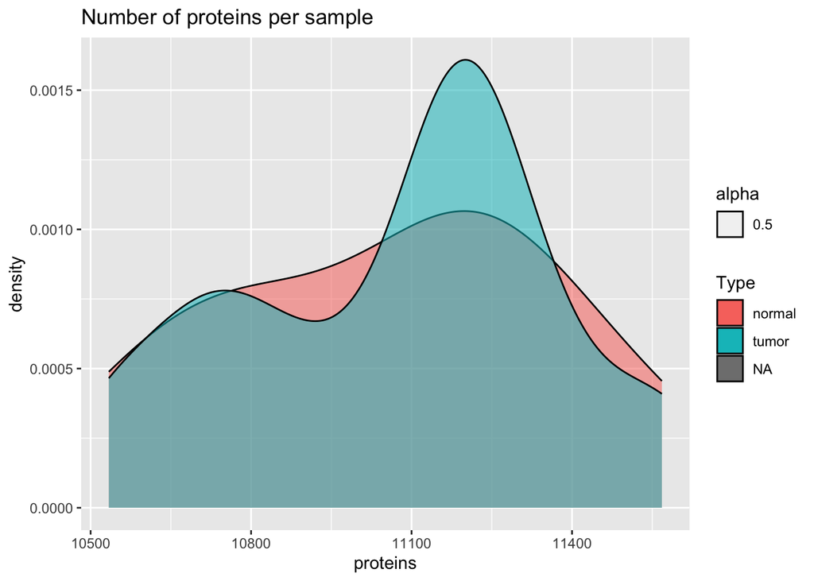

```r
##and plot a summary
pcounts|>
  ggplot(aes(x=proteins,fill=Type,alpha=0.5))+geom_density()+ggtitle('Number of proteins per sample')
```

Now that we have the data loaded and can visualize it, we can no do more advanced integration and analysis.

## Unsupervised clustering of data

The first step in exploring any dataset is unsupervised clustering. This helps us suss out any batch effects of the data, and evaluate any other patterns that might arise. We can cluster the data using principal component analysis (PCA) or other dimensionality reduction tools such as tSNE or UMAP. They each have their biases, so we only show PCA here. PCA is included in the [mixOmics](https://bioconductor.org/packages/release/bioc/html/mixOmics.html) R package, which we leverage here.

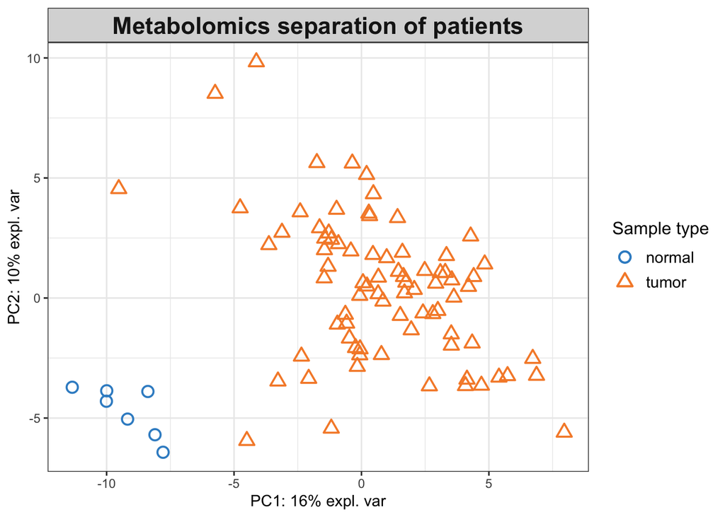

```r
##filter the sample variables and data to make sure they match
## sample information eeds to be separtea
smat<-samps|>
  tibble::column_to_rownames('case_id')


mmat<-met|>
  tidyr::pivot_wider(names_from='CPTAC Participant ID',values_from='intensity')|>
  tibble::column_to_rownames('Metabolite')


##move data to matrix for ploting and analysis
pmat<-prot|>
  dplyr::select(ApprovedGeneSymbol,intensity,`CPTAC Participant ID`)|>
  tidyr::pivot_wider(names_from='CPTAC Participant ID',values_from='intensity')|>
  tibble::column_to_rownames('ApprovedGeneSymbol')

ppats<-intersect(rownames(smat),colnames(pmat))
mpats<-intersect(rownames(smat),colnames(mmat))

##get the principle components using mixOmics
mpca<-mixOmics::pca(t(mmat[,mpats]),scale=TRUE,center=TRUE)
ppca<-mixOmics::pca(t(pmat[,ppats]),scale=TRUE,center=TRUE)

##now plot the samples
mixOmics::plotIndiv(mpca,
          comp=c(1,2),
          ind.names=FALSE,
          group=smat[mpats,]$tumor_normal,
          title='Metabolomics separation of patients',
          legend.title='Sample type',legend=TRUE)
```

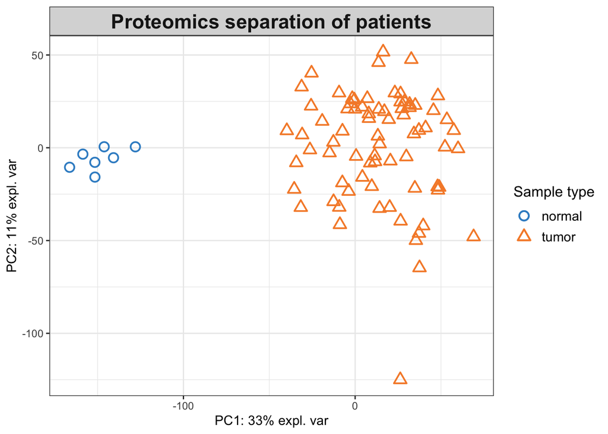

```r
mixOmics::plotIndiv(ppca,
          comp=c(1,2),
          ind.names=FALSE,
          group=smat[ppats,]$tumor_normal,
          title='Proteomics separation of patients',
          legend.title='Sample type',legend=TRUE)
```

As you can see the tumor samples are far more distinct from normal in the proteomics data compared to the metabolomics. However, there is clear separate in each, which begs the question ‘white proteins and metabolites are changed in tumor samples?’

## Partial least squares regression analysis

There is clear division between the two sample types in both the metabolomics and proteomics data. We can now use standard differential expression and pathway enrichment tools to identify those values that are distinct across samples. There are multiple ways to do this but for now we will focus on using the dimensionality reduction techniques employed in `mixOmics`.

```r
##To use mixomics we first must create a list of matrices
osamps<-intersect(samps$case_id,intersect(colnames(pmat),colnames(mmat)))
X <- list(proteomics=t(pmat[,osamps]),metabolomics=t(mmat[,osamps]))
Y<- subset(samps,case_id%in%osamps)|>dplyr::select(tumor_normal)|>unlist()

design<-matrix(0.5,ncol=length(X),nrow=length(X),dimnames=list(names(X),names(X)))
diag(design)<-0.0
design
```

```
##              proteomics metabolomics
## proteomics          0.0          0.5
## metabolomics        0.5          0.0
```

```r
res1.pls <- pls(X$proteomics, X$metabolomics, ncomp = 4)
cor(res1.pls$variates$X, res1.pls$variates$Y)
```

```
##            comp1       comp2         comp3         comp4
## comp1 0.88686578 0.000409711  0.0020680487  6.898835e-04
## comp2 0.16800065 0.824977633 -0.0009308141 -5.164349e-05
## comp3 0.17465733 0.048842747  0.7504435139 -5.856174e-04
## comp4 0.05901257 0.203334957 -0.2000169225  8.192495e-01
```

```r
diablo.met <- block.plsda(X, Y, ncomp = 5, design = design)
```

```
## Design matrix has changed to include Y; each block will be
##             linked to Y.
```

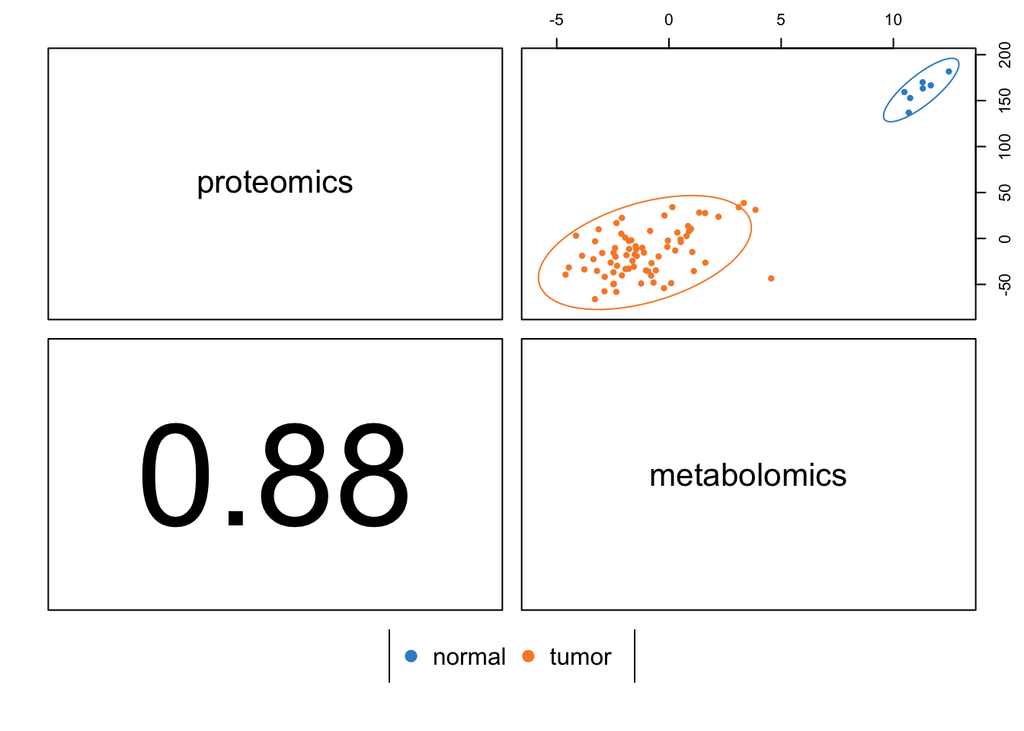

```r
plotDiablo(diablo.met)
```

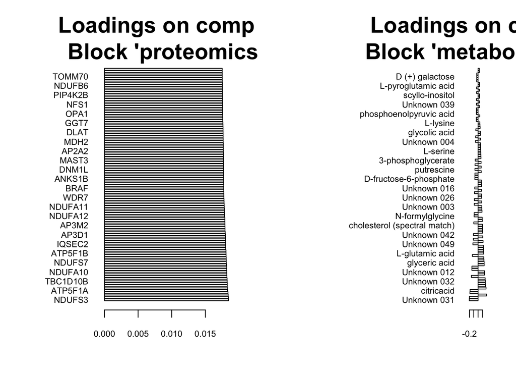

```r
##can we use this to reduce the features?
plotLoadings(diablo.met,ndisplay=100)
```

This plots all the loadings used to distinguish the different sample types. If we want to focus on which metabolites and proteins are most impactful we can examine those that are most negative.

```r
  metloads<-subset(selectVar(diablo.met)$metabolomics$value,value.var< 0)|>
  as.data.frame()|>
  tibble::rownames_to_column('Metabolite')|>
  left_join(kegg_met)
  metweights<-abs(metloads$value.var)
  names(metweights)<-metloads$Metabolite
#  keggloads<-subset(kegg_met,Metabolite%in%rownames(metloads))

  protloads<-subset(selectVar(diablo.met)$proteomics$value,value.var< (-.015))
  protweights<-abs(protloads$value.var)
  names(protweights)<-rownames(protloads)

  print(paste("Selected",length(protweights),'proteins and',length(metweights),'metabolites for subsequent analysis'))
```

```
## [1] "Selected 45 proteins and 66 metabolites for subsequent analysis"
```

## Network-based integration with OmicsIntegrator

Beyond the selection of individual proteins and metabolites, we want to evaluate how these interact with each other in the cell. To do so we collate two different biological network resources. First, we download the data from the [STRING database](http://string-db.org) that includes all physical interactions between proteins and their relative confidence score. Second, we use the [KEGGgraph](https://www.bioconductor.org/packages/release/bioc/html/KEGGgraph.html) R package to retrieve all the [KEGG pathways](https://www.kegg.jp/kegg/pathway.html) that include the detected metabolites.

```r
##load in metabolic network

##i stored the network on github to save time
fullNetwork<-readr::read_csv('https://raw.githubusercontent.com/sgosline/metabolomics-integration/main/mixOmics/kegg_paths_2024.csv')

##remove the pathways that dont contain the metabolites of interest
withPaths<-subset(fullNetwork,from%in%metloads$compoundId)|>
  rbind(subset(fullNetwork,to%in%metloads$compoundId))
reducedNetwork<-subset(fullNetwork,pathway%in%withPaths$pathway)

print(paste('Reducing metabolic network from',length(unique(fullNetwork$pathway)),'pathways to',length(unique(reducedNetwork$pathway))))
```

```
## [1] "Reducing metabolic network from 317 pathways to 10"
```

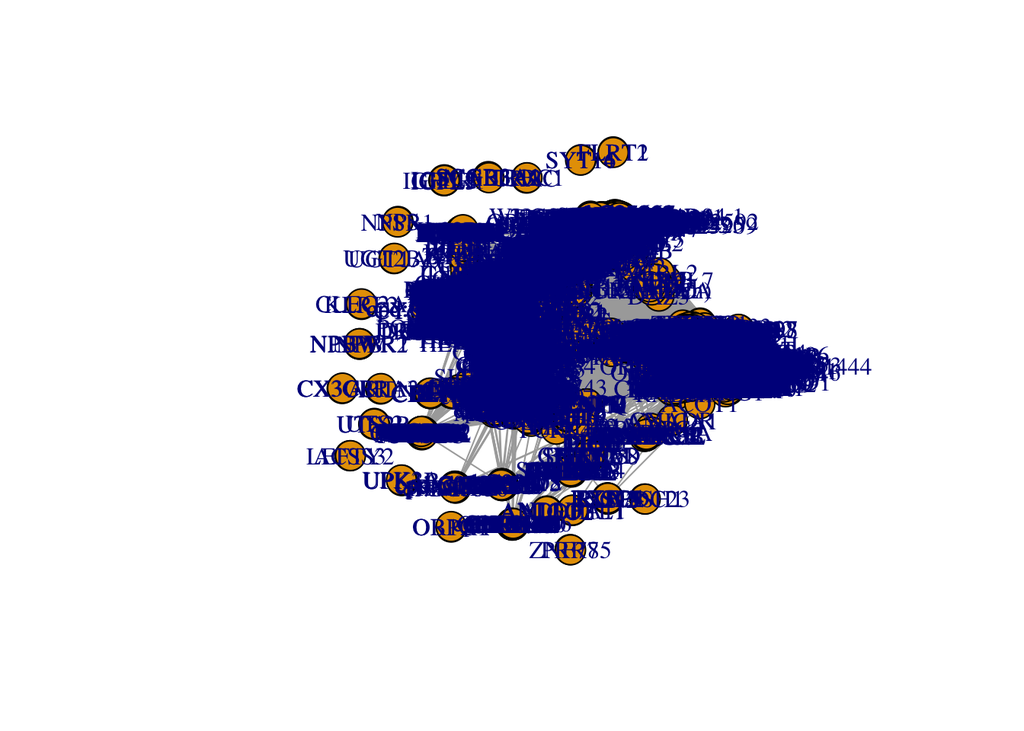

```r
##now move over to gene name and metabolite name
fixedNetwork<-mapNetworkToHGNC(reducedNetwork,kegg_met)

ppi <- addNetworkToProts(fixedNetwork)
plot(ppi)
```

The result is a hairball that is difficult to interpret, as there are too many nodes (molecules) and edges (interactions). To filter the network we use an algorithm from the Prize-Collecting Steiner Forest (PCSF) R package that reduces the graph while keeping the proteins and/or metabolites selected from above.

### Metabolites only

We can take the metabolites that have negative loadings (i.e. they’re more predictive of tumor than normal) and use the quantities from those loadings to weight the molecules in a network. Then we can run PCSF to reduce the network below.

```r
mnet<-PCSF_rand(ppi,metweights,n=5,b=30,w=5)
```

```
##   16.67% of your terminal nodes are included in the interactome
##   Solving the PCSF by adding random noise to the edge costs...
```

```r
plot.PCSF(mnet)
```

[interactive chart not shown]

The result is a small network (there were not that many metabolites that were known and had associated pathways) with the metabolites in green and the inferred protein interactions as triangles in blue.

### Metabolites and proteins

However, we can add in the protein loadings as well (selecting the negative ones and taking the absolute value) to re-run the network analysis in an integrated fashion.

```r
##now get the weights and add to PCSF

nres<-PCSF_rand(ppi,c(metweights,protweights),n=10,b=30)
```

```
##   50.45% of your terminal nodes are included in the interactome
##   Solving the PCSF by adding random noise to the edge costs...
```

```r
plot.PCSF(nres)
```

[interactive chart not shown]

## Summary

Integrating metabolomics with other omics has numerous approaches, and this workshop only scratches the surface. However, we hope that it introduces some tools that can be further explored for your own analysis.